# cole_hw1

Spencer Cole

1/26/2021

## Set working directory and import all packages:

```r
setwd("C:/Users/Spencer Cole/Box/MScEnvironmentalSystems/ES207/Homework/HW#1")
library(tidyverse)
```

## Questions 1-17:

**1. Complete the remaining homework below as a well-commented and easy to follow R Markdown notebook with approriate accompanying text. Turn this in as a .html document. Call it “yourlastname_hw1.html”.**

**2. Using the help documentation, provide an alternative useage for the function ncol().**

An alternative usage to achieve the result of `ncol()` is to use `NCOL()`. `NCOL()` treats the passed vector as a matrix with a single column. Both yield the number of columns in an array.

```r
?"ncol"  # Obtain help for "ncol" function
```

```
## starting httpd help server ... done
```

```r
A <- c("a", "a", "b", "b")  # Define test column 1
B <- c(5, 10, 15, 20)  # Define test column 2
df <- data.frame(A, B)  # Generate a dataframe consisting of the two test columns specified above
ncol(df)  # Check number of columns with ncol()
```

```
## [1] 2
```

```r
NCOL(df)  # Check number of columns with NCOL()
```

```
## [1] 2
```

**3. Using the help documentation, briefly describe the difference between read.csv and tidyverse::read_csv. Type your answer as html text in your R Markdown document (see below).**

The primary difference between the two functions is that `read.csv` reads the dataset as an R `data.frame` object, whereas `read_csv` reads the dataset in the `tibble` format. For many purposes, `read_csv` is faster than `read.csv`.

```r
?"read.csv"
?"read_csv"
```

**4. Can you make R write your name? Print the results to confirm that it worked.**

```r
name <- paste("Spencer", "Allan", "Cole")  # Concatenate my first, middle, and last name into a single string
print(name)  # Print results to confirm
```

```
## [1] "Spencer Allan Cole"
```

**5. What objects are left in your R session after removing m?**

Several objects are present in my R session from previous steps of exercises, including lists `A` and `B`, string `name`, as well as dataframe `df`.

```r
m <- 100  # Define a new variable called "m" to test list function
ls() #  List all objects including "m"
```

```
## [1] "A"    "B"    "df"   "m"    "name"
```

```r
rm(m)
ls()
```

```
## [1] "A"    "B"    "df"   "name"
```

**6. How many odd numbers were in this vector?.**

The `oddcount` function returns a value of 4, which is the correct value for the vector (1,2,3,7,9) which contains 4 odd numbers (1,3,7,9).

```r
oddcount <- function(x)  # Define the oddcount function, which determines the number of odd numbers passed in a vector
{
    k <- 0  # Define k to track the number of odd values in a vector
    for (n in x) {  # Loop for each value in the passed vector
        if(n %% 2 == 1)  # If division of the value by 2 yields a remainder of 1
        {
            k <- k+1  # Add one to the current value of k
        }
    }
  return(k)  # Pass the value of k after looping
}
oddcount(x <- c(1,2,3,7,9))  # Evaluate the oddcount function for a vector x containing the values 1,2,3,7,9
```

```
## [1] 4
```

**7.Try creating a new function “evencount” that counts the even numbers in a vector. Turn in your script as a .R script. Make sure you add appropriate comments - you will be graded on this.**

The `evencount` function is identical to the previous `oddcount` function with the exception that in the evaluation of the `if` statement for the division remainder (using the `%%` operator), the `evencount` function checks if the remainder is zero instead of one. If the remainder is zero, the number must be even. A `print` statement is also added to inform the user which numbers are even.

```r
evencount <- function(x)  # Define the evencount function, which determines the number of even numbers passed in a vector
{
    k <- 0  # Define k to track the number of even values in a vector
    for (n in x) {  # Loop for each value in the passed vector
        if(n %% 2 == 0)  # If division of the value by 2 yields no remainder
        {
            print(paste(n,"is an even number."))
            k <- k+1  # Add one to the current value of k
        }
    }
  print(paste("The total count of even numbers in the vector is:",k))
  return(k)  # Pass the value of k after looping
}
evencount(x <- c(1,2,3,7,9))  # Evaluate the evencount function for a vector x containing the values 1,2,3,7,9
```

```
## [1] "2 is an even number."
## [1] "The total count of even numbers in the vector is: 1"
```

```
## [1] 1
```

**8. What are the three main reasons you want to have a good project layout? Can you think of any others?**

The three primary reasons for having good project layout are: (1) data integrity, (2) project portability, and (3) benefits for picking up a project after a break. Other reasons might be so that the project makes sense to someone outside your organization without having to explain how it is structured in detail. In my research lab, we typically use a fairly consistent project folder structure for each project we work on, which provides consistency and makes it easier to explain locations of documents to others working on the project.

**9. What are the three primary principles to follow in a good project layout?**

The three principles for project layout are to: (1) treat data as “read only”, (2) treat generated output as “disposable”, and (3) define and execute functions in separate scripts.

**10. Write out the full path for your R installation. Use the format of the operating system you are currently using.**

`C:\Program Files\R\R-4.0.3.`

**11. Write the path above using a different operating system.**

Written using the Mac OSX format, the equivalent path would be as follows. The primary difference is the direction of the slashes and the omission of the `C:/` prefix.

`/Program Files/R/R-4.0.3`

**12. Write out the full path for the directory structure you have set up for this class all the way to where you have saved this .html tutorial.**

`C:\Users\Spencer Cole\Box\MScEnvironmentalSystems\ES207\Homework\HW#1\hw_01_intro_to_R_and_RMarkdown.html`

**13. Write out the relative path for this .html file assuming your working directory to be set to your equivalent of Users/CardiB/classes/**

`\Homework\HW#1\hw_01_intro_to_R_and_RMarkdown.html`

**14. Write out the paths in an operating system other than your own.**

Again in the Mac OSX format, these paths would be as follows.

`/Users/Spencer Cole/Box/MScEnvironmentalSystems/ES207/Homework/HW#1/hw_01_intro_to_R_and_RMarkdown.html` `/Homework/HW#1/hw_01_intro_to_R_and_RMarkdown.html`

**15. Use ggplot to make a scatter plot that visualizes the relationship between chlorophyll-a chla and total phosphorous TP. Hint - check your R for Data Science text!**

Only roughly 90 points are plotted as the majority of the dataframe is missing values for `chla`, as indicated by a message provided by R.

```r
erie1 <- read_csv('LakeErie1.csv')  # Read data for Lake Erie using the read_csv function from tidyverse
```

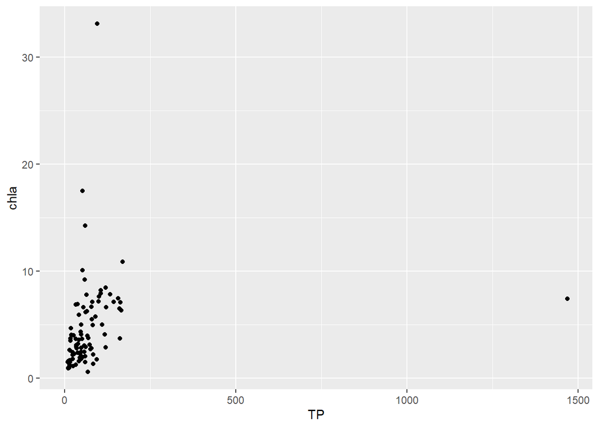

```r
ggplot(data = erie1) +  # Create the plot and inform it that your data will come from the dataframe "erie"
  geom_point(mapping = aes(x = TP, y = chla))  # Add a scatter geom where the x axis is the "TP" parameter and the y axis is "chla"
```

**16. How many observations (rows) have missing TP values? Hint - check your R for Data Science text!**

A pop-up message from R informs us in the previous plotting process that 640 rows were removed for containing `NA` values in at least one column. We can check the number of missing values for `TP` using the `mutate` function to add a column to `erie` tracking when a `NA` value is listed for `TP`. We then summarize the count of `NA` values using a conditional `sum()` function and display the result.

```r
erie2 <- read_csv('LakeErie1.csv') %>%  # Read data for Lake Erie using the read_csv function from tidyverse
  mutate(  # Edit the dataframe that was just imported
    TP_na = is.na(TP)
    ) %>%  # Add a column to track NA values for "TP"
  summarise(  # Create a concise summary of the previous mutated dataframe
    count_TP_na = sum(TP_na == 'TRUE')  # Summarize by adding a new term "count_TP_na" which sums the number of NA values in the new column
    )
erie2$count_TP_na[[1]]  # Display the value of the first row of the dataframe "erie" in the column titled "count_TP_na"
```

```
## [1] 77
```

**17. Challenge question! Water quality data are often transformed to a log-scale (more about this later). Use the mutate function to create a new variable column for a) TP, and b) pMC. Hint - check your R for Data Science text! Another hint you can’t take the log of zero. What are you going to do?**

The `log10` function can be used to evaluate both the `TP` and `pMC` values. Evaluating a log of 0 in R will return `-Inf`. We can use a compound filter on our dataframe with the `is.finite()` function to remove non-finite values for these two parameters, which includes both `NA` values and `-Inf` values.

```r
erie3 <- read_csv('LakeErie1.csv') %>%  # Read data for Lake Erie using the read_csv function from tidyverse
  mutate(  # Edit the dataframe that was just imported
    TP_log = log10(TP),  # Calculate a new column as the log of "TP"
    pMC_log = log10(pMC)  # Calculate a new column as the log of "pMC"
    )
erie3 <- erie3[is.finite(erie3$TP_log) & is.finite(erie3$pMC_log), ]  # Remove all rows where either log value is either NA or infinite
erie3  # Display the new dataframe
```

```
## # A tibble: 565 x 43
##    Station  Year Day   Date  Time  Latitude Longitude Depth Secchi  Temp   Co0
##    <chr>   <dbl> <chr> <chr> <tim>    <dbl>     <dbl> <dbl>  <dbl> <dbl> <dbl>
##  1 LE1      2008 26-J~ 6/26~    NA     41.8      83.1    NA    3.4    NA    NA
##  2 LE2      2008 26-J~ 6/26~    NA     41.8      83.2    NA    4.9    NA    NA
##  3 LE3      2008 26-J~ 6/26~    NA     41.8      83.4    NA    3.2    NA    NA
##  4 LE4      2008 26-J~ 6/26~    NA     41.7      83.4    NA    2.2    NA    NA
##  5 LE5      2008 26-J~ 6/26~    NA     41.7      83.5    NA    0.2    NA    NA
##  6 LE6      2008 26-J~ 6/26~    NA     41.7      83.3    NA    1.4    NA    NA
##  7 LE7      2008 26-J~ 6/26~    NA     41.7      83.2    NA    2.4    NA    NA
##  8 LE8      2008 26-J~ 6/26~    NA     41.8      83.3    NA    1.9    NA    NA
##  9 LE9      2008 26-J~ 6/26~    NA     41.8      83.1    NA    2.5    NA    NA
## 10 LE10     2008 26-J~ 6/26~    NA     41.9      83.2    NA    2.4    NA    NA
## # ... with 555 more rows, and 32 more variables: SpCo0 <dbl>, BeamAtten <dbl>,
## #   Transmission <dbl>, chla <dbl>, PC <dbl>, PAR <dbl>, DO <dbl>,
## #   au.chl <dbl>, AquaFluor_PC <dbl>, AquaFluor_CHL <dbl>, Turbidity <dbl>,
## #   TP <dbl>, TDP <dbl>, SRP <dbl>, NH4 <dbl>, NO3 <dbl>, SiO2 <dbl>, Cl <dbl>,
## #   TSS <dbl>, VSS <dbl>, POC <dbl>, PON <dbl>, DOC <dbl>, ExChla <dbl>,
## #   ExPC <dbl>, pMC <dbl>, dMC <dbl>, pMC_LC_MS <dbl>, TCyanos_cells <dbl>,
## #   TCyanos_volume <dbl>, TP_log <dbl>, pMC_log <dbl>
```